# Algebraic Geometry

# 26 Projections and Embeddings (Tuesday, November 17)

## 26.1 Projecting From a Point

We have ${\mathbb{P}}^n \mathrel{\vcenter{:}}={\mathbb{A}}^{n+1}\setminus\left\{{0}\right\}/ \sim$ where $x\sim \lambda x$, and projective varieties $V(I) \subset {\mathbb{P}}^n$ where $I {~\trianglelefteq~}k[x_0, \cdots, x_n]$ is a homogeneous ideal. We defined a sheaf of rings ${\mathcal{O}}_X$ on $X = V(I)$ by
$$\begin{align*}
{\mathcal{O}}_X(U) \mathrel{\vcenter{:}}=\left\{{\phi: U\to k {~\mathrel{\Big|}~}\phi \text{ is locally a ratio of two homogeneous polynomials of equal degree}}\right\}
.\end{align*}
We showed that this was the same as the sheaf \(\tilde {\mathcal{O}}_X\) defined by gluing ringed spaced \((X \cap U_i, {\mathcal{O}}_{X\cap U_i})\) where \(U_i = D(x_i)\). We also showed that \(S(X) \mathrel{\vcenter{:}}= k[x_0, \cdots, x_n] / I(X)\) is homogeneous, i.e. the quotient by a homogeneous ideal is again homogeneous. Moreover, if \(\left\{{f_i}\right\}_{i=0}^m \subseteq S(X)_d\) and \(V(\left\{{f_i}\right\}) = \emptyset\). then the map
\begin{align*}
(f_0, \cdots, f_m): X &\to {\mathbb{P}}^m \\
x &\mapsto [f_0(x), \cdots, f_m(x)]
.\end{align*}$$

Recall that a variety is separated iff $\Delta \hookrightarrow X$ is closed. Let $A\in \operatorname{GL}_{n+1}(k)$ and define a map
$$\begin{align*}
A: {\mathbb{P}}^n &\to {\mathbb{P}}^n \\
\begin{bmatrix}
x_0 \\
\vdots \\
x_n
\end{bmatrix}
&\mapsto
A
\begin{bmatrix}
x_0 \\
\vdots \\
x_n
\end{bmatrix}
.\end{align*}$$

This is a morphism because
$$\begin{align*}
\begin{bmatrix}
- & \vec A_0 & - \\
- & \vdots & - \\
- & \vec A_n & - \\
\end{bmatrix}
\begin{bmatrix}
x_0 \\
\vdots \\
x_n
\end{bmatrix}
=
\begin{bmatrix}
A_0 \cdot \mathbf{x} \\
\vdots \\
A_n \cdots \mathbf{x}
\end{bmatrix}
,\end{align*}
which are linear homogeneous polynomials.$$

Then $V_p(A_i \cdot \mathbf{x}) = \emptyset$, and thus $V_a(A_i \cdot \mathbf{A}) = \left\{{0}\right\}$. So we should view $A\in \operatorname{PGL}_{n+1}(k)$. Note that this is a group, since $A^{-1}$ again forms a morphism. Thus $\operatorname{PGL}_{n+1}(k) \subset {\operatorname{Aut}}({\mathbb{P}}^n)$, and it turns out that these are in fact equal.

Let $a = [1: 0 : \cdots : 0] \in {\mathbb{P}}^n$, then there is a morphism
$$\begin{align*}
{\mathbb{P}}^n \setminus\left\{{a}\right\} &\to {\mathbb{P}}^{n-1} \\
[x_0: \cdots : x_n] &\mapsto [x_1: \cdots : x_n]
.\end{align*}
Note that this morphism does not extend to \({\mathbb{P}}^n\). More generally, given any point \(p\in {\mathbb{P}}^n\), we can project from it by making a linear change of coordinates to \(p = [1: 0 : \cdots : 0]\).$$

Let $x\in {\mathbb{P}}^n\setminus\left\{{a}\right\}$, then there is a unique line through $a$ and $x$. It can be described parametrically as follows: writing $x = [x_0: \cdots : x_n]$, we take the plane they span and projectivize to obtain $s[x_0 : \cdots : x_n] + t [1: 0 : \cdots : 0]$ where we range over $[s: t] \in {\mathbb{P}}^1$. In fact, this defines a morphism ${\mathbb{P}}^1 \to {\mathbb{P}}^n$.

Consider now ${\mathbb{P}}^{n-1} = V(x_0)$, this copy of ${\mathbb{P}}^{n-1}$ intersects any such line at a unique point:

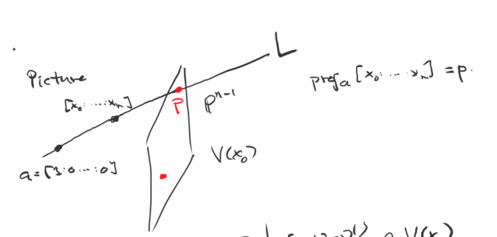

Copy of ${\mathbb{P}}^{n-1}$ intersecting a line.

Consider $X = V(x_0 x_2 - x_1^2) \subset {\mathbb{P}}^2$, which defines a conic, and the projection ${\mathbb{P}}^2 \setminus\left\{{[1:0:0]}\right\} \to {\mathbb{P}}^1$:

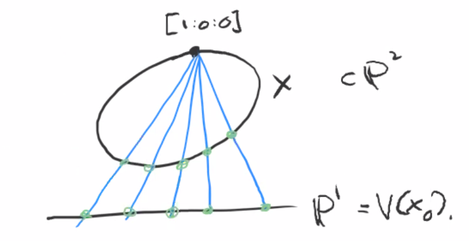

Projection from $V(x_0 x_2 - x_1^2)$ onto $V(x_0)$.

This locally writes $\phi$ as a morphism, so we only need to check that they agree on the overlap. Note that on $X$, we have $[x_1: x_2] = [x_0 : x_1]$ wherever both are well-defined. In fact, $\mkern 1.5mu\overline{\mkern-1.5mu\phi\mkern-1.5mu}\mkern 1.5mu$ is an isomorphism, since an inverse can be explicitly written. Thus $X\cong {\mathbb{P}}^1$, and in fact all nondegenerate[^13] conics are isomorphic to ${\mathbb{P}}^1$ as well. Note that such a $Q$ is a quadratic form, so $Q(x) = B(x, x)$ for some bilinear form, and $Q$ is nondegenerate iff $\det B \neq 0$ where $B_{ij} = B(e_i, e_j)$.

## 26.2 The Segre Embedding

Letting $N = (n+1)(m+1) - 1$, the **Segre embedding** is the morphism
$$\begin{align*}
f: {\mathbb{P}}^n \times{\mathbb{P}}^m &\to {\mathbb{P}}^N \\
([x_0: \cdots : x_n], [y_0: \cdots : y_m]) &\mapsto
[x_0 y_0 : \cdots : z_{ij} \mathrel{\vcenter{:}}= x_i y_j : x_n y_m]
.\end{align*}$$

Note that ${\mathbb{P}}^n, {\mathbb{P}}^m$ are prevarieties and we thus know how to construct their product as a prevariety. Check that this is well-defined!

1. The image $X$ is a projective variety.
2. $f: {\mathbb{P}}^n \times{\mathbb{P}}^m \to X$ is a morphism.

It suffices to write polynomials in the coordinate $z_{ij}$ that cut out $f({\mathbb{P}}^n \times{\mathbb{P}}^m)$. Given $z_{ij} = x_i y_j$, we have $z_{ij} z_{kl} = z_{il} z_{kj}$ and $(x_i y_j)(x_k y_l) = (x_i y_l)(x_k y_j)$. The former quadric equations in $z_{ij}$ variables vanish on $f({\mathbb{P}}^n \times{\mathbb{P}}^m)$.

$V(z_{ij} z_{kl} - z_{il} z_{kj})$ works.

Without loss of generality, we can assume $z_{00} = 1$, in which case $z_{ij} z_{00} = z_{ij} = z_{i0} z_{0j}$ on $X$. Setting $x_i = z_{i0}$ and $y_j = z_{0j}$, we’ve now constructed a point in the preimage, so $f$ surjects onto $X$.

That $f$ is a morphism to ${\mathbb{P}}^n$ is easy, and since $\operatorname{im}f \subset X$, $f: {\mathbb{P}}^n \times{\mathbb{P}}^m \to X$ is a morphism. On $D(z_{00}) \subset X$, the inverse described above is a morphism. Since this works for any $z_{ij}$, $f^{-1}$ is well-defined and a morphism, making $f$ an isomorphism.

Take

\begin{align*} f: {\mathbb{P}}^1 \times{\mathbb{P}}^1 &\to {\mathbb{P}}^3 \\ \qty{ {\left[ {x_0: x_1} \right]}, {\left[ {y_0: y_1} \right]}} &\mapsto {\left[ {z_{00} : z_{01} : z_{10} : z_{11} } \right]} \mathrel{\vcenter{:}}={\left[ {x_0 y_0: x_0 y_1 : x_1 y_0 : x_1 y_1} \right]} .\end{align*} Restricting to $\operatorname{im}(f)$ yields an isomorphism to $X \subseteq {\mathbb{P}}^3$ given by the quadric[^14] $X = V(z_{00} z_{11} - z_{10} z_{01} )$.

# 27 Projective Varieties (Thursday, November 19)

## 27.1 Why use projective varieties?

For e.g. a manifold, there is a well-defined intersection pairing, and the same way that $[\mu] \in H^1(T, {\mathbb{Z}}) = 1$ in the torus, we have $[L]^2 = 1$ in ${\mathbb{P}}^2_{/{\mathbb{C}}}$, so every two lines intersect in a unique point. Also, Bezout’s theorem: any two curves of degrees $d, e$ in projective space intersect in $d\cdot e$ points. Also note that we have a notion of compactness that works in the projective setting but not for affine varieties.

## 27.2 Projective Varieties are Varieties

Last time: we saw the Segre embedding $(\mathbf{x}, \mathbf{y})\mapsto [x_i y_j]$, which was an isomorphism onto its image $X = V(z_{ij}z_{kl} - z_{ik} z_{kj} )$, which exhibits ${\mathbb{P}}^n \times{\mathbb{P}}^m$ as a projective variety.

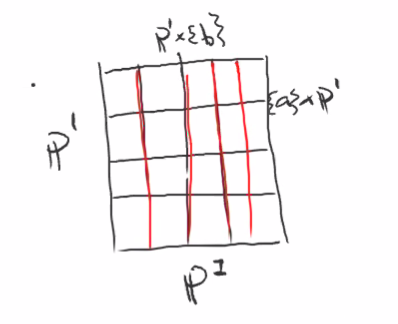

${\mathbb{P}}^1 \times{\mathbb{P}}^1$ is ruled.

The projection map has fibers, which induce a **ruling**[^15] which we can see from the real points:

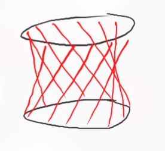

Its image, a quadric surface, is also ruled.

Every projective variety is a separated prevariety, and thus a variety.

It suffices to show that $\Delta_X \subset X\times X$ is closed. We can write
$$\begin{align*}
\Delta_{{\mathbb{P}}^n} =
\left\{{
[x_0: \cdots: x_n], [y_0: \cdots : y_n] {~\mathrel{\Big|}~}
x_i y_j - x_j y_i = 0 \, \forall i, j
}\right\}
.\end{align*}
This says that \(\mathbf{x}, \mathbf{y}\) differ by scaling. We know that \(\Delta_{{\mathbb{P}}^n} \hookrightarrow{\mathbb{P}}^n \times{\mathbb{P}}^n\), which is isomorphic to the Segre variety \(S_V\) in \({\mathbb{P}}^{(n+1)^2 -1}\), and we can write \(z_{ij} = x_i y_j\) and thus
\begin{align*}
\Delta_{{\mathbb{P}}^n} = S_V \cap V(z_{ij} - z_{ji})
.\end{align*}
Note that the Segre variety is closed. The conclusion is that \({\mathbb{P}}^n\) is a variety, and any closed subprevariety of a variety is also a variety by taking \(\Delta_{{\mathbb{P}}^n} \cap(X\times X) = \Delta_X\), which is closed as the intersection of two closed subsets.$$

Recall that a map $f:X\to Y$ is topological spaces is **closed** if whenever $U \subset X$ is closed, then $f(U)$ is closed in $Y$.

A variety $X$ is **complete** if the projection $\pi_Y: X\times Y \twoheadrightarrow Y$ is a closed map for any $Y$.

Completeness is the analog of compactness for varieties.

The projection ${\mathbb{P}}^n \times{\mathbb{P}}^m \to {\mathbb{P}}^m$ is closed.

Let $Z \subset {\mathbb{P}}^n \times{\mathbb{P}}^m$, and write $Z = V(f_i)$ with $f_i \in S(S_V)$. Note that if the $f_i$ are homogeneous of degree $d$ in $z_{ij}$, the pulling back only the isomorphism ${\mathbb{P}}^n\times{\mathbb{P}}^m \to S_V$ yields $z_{ij} = x_i y_j$ and polynomials $h_i$ which are homogeneous polynomials in $x_i, y_j$ which have degree $d$ in both the $x$ and $y$ variables individually. Consider $a\in {\mathbb{P}}^m$, we want to determine if $a\in \pi(Z)$ and show that this is a closed condition. Note that $a\not\in \pi(Z)$

- $\iff$ there does not exists an $x\in {\mathbb{P}}^n$ such that $(x, a) \in Z$
- $\iff$ $V_p(f_i(x, a))_{i=1}^r = \emptyset$
- $\iff$ $\sqrt{\left\langle{f_i(x, a)}\right\rangle_{i=1}^r } = \left\langle{1}\right\rangle$ or the irrelevant ideal $I_0$
- $\iff$ there exist $k_i \in {\mathbb{N}}$ such that $x_i^{k_i} \in \left\langle{f_i(x, a)}\right\rangle_{i=1}^r$
- $\iff$ $k[x_1, \cdots, x_{n}]_k \subset \left\langle{f_i(x, a)}\right\rangle_{i=1}^r$ (where this is the degree $k$ part)
- $\iff$ the map
  $$\begin{align*}
  \Phi_a: k[x_1, \cdots, x_{n}]_{d - \deg f_2} \oplus \cdots \oplus k[x_1, \cdots, x_{n}]_{d - \deg f_r} &\to k[x_1, \cdots, x_{n}]_d \\
  (g_1, \cdots, g_r) &\mapsto \sum f_i(x, a) g_i (x, a)
  \end{align*}
  is surjective.$$

Recap: we have a closed subset of ${\mathbb{P}}^n \times{\mathbb{P}}^m$, want to know its projection is closed. We looked at points not in the closed set, this happens iff the degree $d$ part of the polynomial is not contained in the part where we evaluate by $a$. This reduces to a linear algebra condition: taking arbitrary linear combinations yields a surjective map. Thus $a\in \pi(Z)$ iff $\Phi_a$ is *not* surjective.

The projection $\pi: {\mathbb{P}}^n\times Y\to Y$ is closed for any variety $Y$ and thus ${\mathbb{P}}^n$ is complete.

How to prove anything for varieties: use the fact that they’re glued from affine varieties, so prove in that special case. So first suppose $Y$ is affine. Let $Z \subset {\mathbb{P}}^n \times Y$ be closed, and consider $\mkern 1.5mu\overline{\mkern-1.5muY\mkern-1.5mu}\mkern 1.5mu ss {\mathbb{P}}^m$ and
$$\begin{align*}
\mkern 1.5mu\overline{\mkern-1.5muZ\mkern-1.5mu}\mkern 1.5mu \subset{\mathbb{P}}^n \times\mkern 1.5mu\overline{\mkern-1.5muY\mkern-1.5mu}\mkern 1.5mu \subset{\mathbb{P}}^n \times{\mathbb{P}}^m
\end{align*}
as a closed subset. Then we know that the projection \(\pi: {\mathbb{P}}^n \times{\mathbb{P}}^m \to {\mathbb{P}}^m\) is closed, so \(\pi(\mkern 1.5mu\overline{\mkern-1.5muZ\mkern-1.5mu}\mkern 1.5mu) \subset{\mathbb{P}}^m\) is closed. But we can write
\begin{align*}
\pi(Z) = \pi(\mkern 1.5mu\overline{\mkern-1.5muZ\mkern-1.5mu}\mkern 1.5mu \cap{\mathbb{P}}^n \times Y) = \pi(\mkern 1.5mu\overline{\mkern-1.5muZ\mkern-1.5mu}\mkern 1.5mu) \cap Y
\end{align*}
which is closed. So \(\pi(Z)\) is closed in \(Y\), which proves this for affine varieties.$$

Supposing now that $Y$ is instead glued from affines, it suffices to check that the set is closed in an open cover. So $Z \subset X$ is closed if when we let $X = \cup U_i$, we can show $Z \cap U_i$ is closed. But this essentially follows from above.

Any projective variety is complete.

If $X \subset {\mathbb{P}}^n$ is closed and if ${\mathbb{P}}^n \times Y\to Y$ is a closed map for all $Y$, then restricting to $X\times Y\to Y$ again yields a closed map.

Let $f:X\to Y$ be a morphism of (importantly) *varieties* and suppose $X$ is complete. Then $f(X)$ is closed in $Y$.

Consider the graph of $f$,
$$\begin{align*}
\Gamma_f = \left\{{(x, f(x))}\right\} \subset X\times Y
\end{align*}
From a previous proof, we know \(\Gamma_f\) is closed when \(Y\) is a variety (by pulling back a diagonal). So \(\Gamma_f\) is closed in \(X\times Y\), and thus \(\pi_Y(\Gamma_f) = f(X)\) is closed because \(X\) is complete.$$

The next result is an analog of the maximum modulus principle: if $X$ is a compact complex manifold, then any function that is holomorphic on all of $X$ is constant.

Let $X$ be complete, then ${\mathcal{O}}_X(X) = k$, i.e. every global regular function is constant.

Suppose $\phi X\to {\mathbb{A}}^1$ is a regular function. Since ${\mathbb{A}}^1 \subset {\mathbb{P}}^1$, extend $\phi$ to a morphism $\widehat{\phi}: X\to PP^1$. By a previous corollary, $\phi(X)$ is closed, but $\infty \not\in \phi(X)$ implies $\phi(X) \neq {\mathbb{P}}^2$, so $\phi(X)$ is finite. Since $X$ is connected, $\phi(X)$ is a point, making $\phi$ a constant map.

# 28 Embeddings and Smoothness (Tuesday, November 24)

## 28.1 The Veronese Embedding

Let $n, d > 0$ and let $f_0, \cdots, f_n$ be the monomials of degree $d$ in $k[x_1, \cdots, x_{n}]$. There is a morphism
$$\begin{align*}
{\mathbb{P}}^n \setminus V(f_0,\cdots , f_n) &\to {\mathbb{P}}^N \\
\mathbf{x} &\mapsto [f_0(\mathbf{x}), \cdots, f_N(\mathbf{x})]
,\end{align*}
where \(N+1\) is the number of monomials, and is equal to \({n+d \choose d}\).$$

### 28.1.1 Exchanging Hypersurface Sections for Hyperplane Sections

This embedding converts hypersurfaces of degree $d$ into hyperplanes. The Veronese is an isomorphism onto its image. Consider some arbitrary degree $d$ element of $S({\mathbb{P}}^n)$. Consider $X \mathrel{\vcenter{:}}= V(\sum_{j=1}^N a_j f_j) \subset{\mathbb{P}}^n$, where $a_j\in k$, which is equal to $\phi^{-1}(V(\sum_{j=1}^N a_j w_j ))$.

We have a picture: embedding ${\mathbb{P}}^n\hookrightarrow{\mathbb{P}}^N$ in some curved way sends a hypersurface to the intersection of a hyperplane with the embedded image:

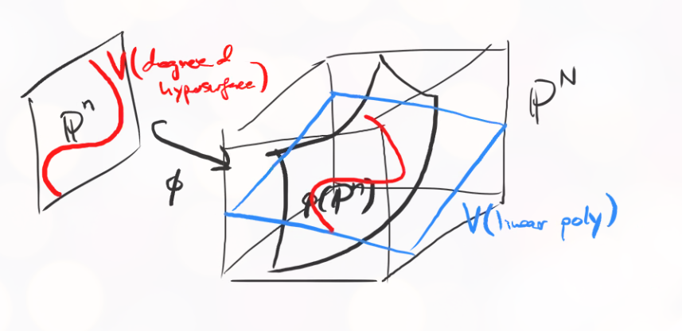

Embedding a hypersurface into a hyperplane.

Let $X \subset{\mathbb{P}}^n$ be a projective variety. A **hyperplane section** is the intersection of $X$ with some hyperplane $H \mathrel{\vcenter{:}}= V(f)$ for $f$ some linear homogeneous polynomial.

Let $n=1$, then we get the embedding \begin{align*} {\mathbb{P}}^1 &\hookrightarrow{\mathbb{P}}^d \\ [x_0: x_1] &\mapsto [x_0^d: x_0^{d-1}x_1 : \cdots : x_0 x_1^{d-1} : x_1^d] .\end{align*} Note that there are $d+1$ such monomials, and not all can simultaneously vanish. The image of this ${\mathbb{P}}^1$ is called the *twisted normal curve*.

Take
$$\begin{align*}
{\mathbb{P}}^1 &\hookrightarrow{\mathbb{P}}^2 \\
[x_0 : x_1] &\mapsto [x_0^2 : x_0 x_1: x_1^2]
.\end{align*}
What homogeneous polynomials cut out \(\phi({\mathbb{P}}^1)\)? I.e., what is \(I(\phi({\mathbb{P}}^1)) \subset S({\mathbb{P}}^2)\)? Note that \(w_0 w_2 - w_1^2 { \left.{{}} \right|_{{\phi({\mathbb{P}}^1)}} }\), so this is an element. Is it a generator? I.e., given any \(p\in V(w_0 w_2 - w_1^2)\) is of the form \(p = [x_0^2 : x_0 x_1: x_1^2]\) for some \(x_), x_1 \in k\)? The answer is yes, by choosing signs of \(\sqrt{w_0}, \sqrt{w_2}\).$$

Take
$$\begin{align*}
\phi: {\mathbb{P}}^1 &\hookrightarrow{\mathbb{P}}^3 \\
[x_0: x_1] &\mapsto [x_0^3: x_0^2 x_1 : x_0 x_1^2: x_1^3]
.\end{align*}
What are some elements of this ideal?$$

- $w_0 w_3 - w_1 w_2$
- $w_0 w_2 - w_1^2$
- $w_1 w_3 - w_2^2$

Note that the first is not a $k{\hbox{-}}$linear combination of the other two. There is also a pattern: $w_0/w_1 = w_1 / w_2 = w_2/w_3 = \cdots$. However, there will be issues when the denominators are zero.

In this case, $\phi({\mathbb{P}}^1)$ is the *twisted cubic*. What is $V(w_0 w_2 - w_1^2, w_1 w_3 - w_2^2) \setminus\phi({\mathbb{P}}^1)$? Note that being in $\phi({\mathbb{P}}^1)$ means $w_1, w_2, w_3 \neq 0$, and similarly if $w_0, w_1, w_2 \neq 0$. We can conclude that $V(w_1, w_2) \subset V(w_0 w_2 - w_1^2, w_1 w_3 - w_2^2)$:

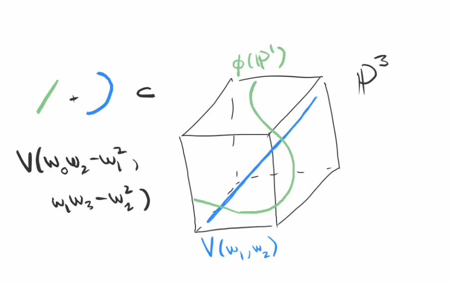

Image

This variety has two components: the twisted cubic, and a line. This variety has degree 4, since any generic hyperplane intersects it at 4 points. Why? Pulling back a hyperplane yields a cubic, which generally vanishes at three points in affine space.

$\phi({\mathbb{P}}^1)$ is a nice example of a curve in ${\mathbb{P}}^3$ that can not be cut out by two homogeneous polynomials.

This is usually used to embed intersections like $X\cap V(f)$ to $X\cap H$, exchanging a hypersurface section for a hyperplane section. This is useful for induction:

1. Prove for ${\mathbb{P}}^n$.
2. Induction: If it’s true for $X \subset{\mathbb{P}}^n$, then it’s true for $X \cap H$ for some hyperplane $H \subset{\mathbb{P}}^N$.

This will prove it for any projective variety by taking $X = V(f_1, \cdots, f_n)$ and embedding.

## 28.2 The Tangent Space (Chapter 10)

Motivation: we want to distinguish between things like $V(xy)$ and $V(xy-1)$. Over ${\mathbb{C}}$, we can distinguish these: one is a complex manifold, and the other is not.

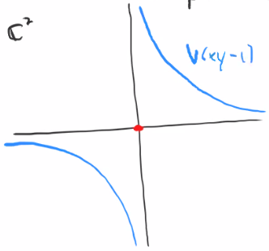

$V(xy-1)$ is a manifold in ${\mathbb{C}}^2$

This means we want each point to have a neighborhood biholomorphic to a disc.

Let $a\in X$ be a point on a variety $X$. Choose an affine open set containing $a$ and a chart such that $a$ is the origin, then define
$$\begin{align*}
T_a X \mathrel{\vcenter{:}}= V(f_1 {~\mathrel{\Big|}~}f\in I(X))
,\end{align*}
where \(f_1\) denotes the linear part of \(f\).$$

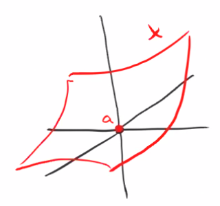

Tangent space at a point.

Since $0=a$, any $f\in I(X)$ has no constant term – otherwise $f$ would not vanish at the origin.

Consider $T_{(1, 1)} V(xy-1)$. First translate $(1, 1)$ to the origin, so
$$\begin{align*}
T_{(1, 1)} V(xy-1) = T_{(0, 0)} = V((x-1)(y-1) - 1) = T_{(0, 0)} V(xy-x-y) = V(-x-y)
\end{align*}
On the other hand, \(T_{(0, 0)} V(xy) = V(0) = {\mathbb{C}}^2\).$$

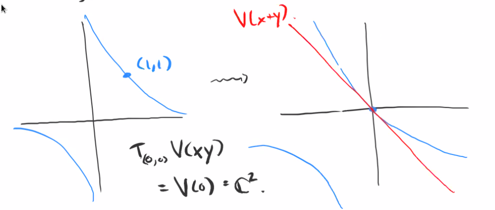

Image

# 29 The Tangent Space and Smoothness (Tuesday, December 01)

The **tangent space** $T_p X$ of a variety $X$ at a point $p\in X$ is defined as
$$\begin{align*}
V\qty{\left\{{f_1 {~\mathrel{\Big|}~}f\in I(U_i),\, U_i \ni p = 0 \text{ affine } }\right\}}
\end{align*}
where \(f_1\) denotes the degree 1 part.$$

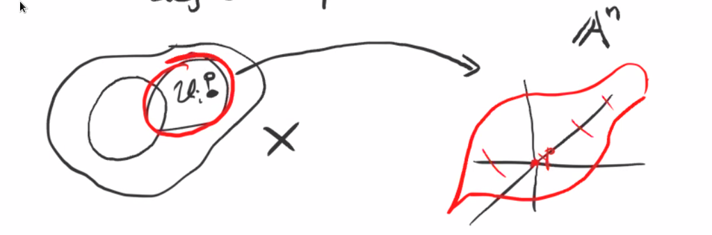

Image

We’ve really only defined it for affine varieties and $p=0$, but this is a local definition. Note that this is also not a canonical definition, since it depends on the affine chart $U_i$.

## 29.1 Computing Tangent Spaces

Let $X = V_p(xy-z^2) \subset {\mathbb{P}}^2$, which is a projective curve. What is $T_p X$ for $p = [0:1:0]$? Take an affine chart $\left\{{y\neq 0}\right\} \cap X$, noting that $\left\{{y\neq 0}\right\} \cong {\mathbb{A}}^2$. We could dehomogenize the ideal ${ \left.{{\left\langle{xy-z^2}\right\rangle}} \right|_{{y=1}} } = \left\langle{x-z^2}\right\rangle$. Thus $X \cap D(y) = V(x-z^2) \subset {\mathbb{A}}^2$ and the point $[0:1:0] \in X$ gives $(0, 0)$ in this affine chart. Then
$$\begin{align*}
T_p X = V(f_1 {~\mathrel{\Big|}~}f\in \left\langle{x-z^2}\right\rangle) = V(x)
\end{align*}
Then \(f = (x-z^2)g\) implies that \(f_1 = (xg)_1 = g_0 x\), the constant term of \(g\) multiplied by \(x\), since \(z^2\) kills any degree 1 part of \(g\). So \(T_p X\) is a line.$$

Take $X$ to be the union of the coordinate axes in ${\mathbb{A}}^3$:

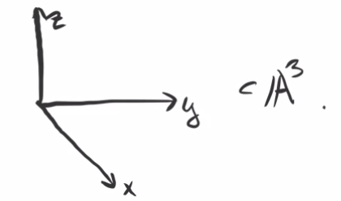

The coordinate axes in ${\mathbb{A}}^3$.

Then $I(X) = \left\langle{xy, yz, xz}\right\rangle$ and
$$\begin{align*}
T_0 X = V(f_1 {~\mathrel{\Big|}~}f\in I(X)) = V(0) = {\mathbb{A}}^3
\end{align*}
since the minimal degree of any such polynomial is 2. Note that \(\dim X = 1\) but \(\dim T_0 X = 3$$

Take $Y = V(xy(x-y)) \subset {\mathbb{A}}^2$:

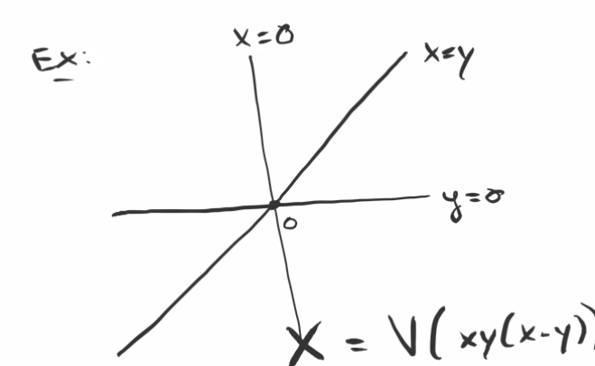

$V(xy(x-y))$ in ${\mathbb{A}}^2$.

Then $T_0 X = V(0) = {\mathbb{A}}^2$.

Note that $X$ and $Y$ both consists of 3 copies of ${\mathbb{A}}^1$ intersecting at a single point.

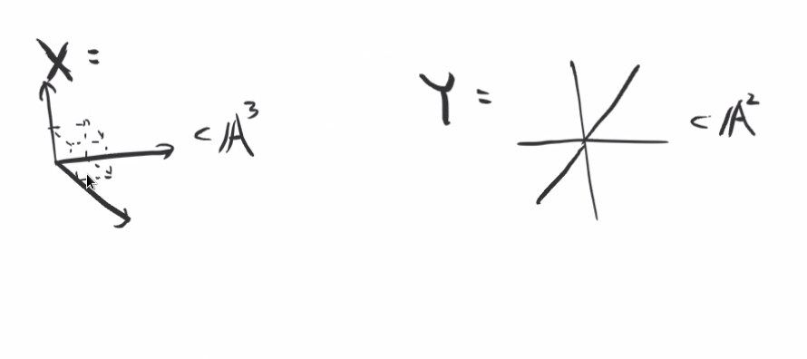

Comparing $X$ and $Y$.

Note that $\dim T_0 X = 3$ but $\dim T_0 Y = 2$, and interestingly $X\not\cong Y$ as affine varieties. There is a bijective morphism that is not invertible.

We will prove that $\dim T_p X$ is invariant under choice of affine embedding.

First move $(1,0,0)$ to the origin, yielding $T_{(0,0,0)} V((x+1)y, yz, (x+1) z)$. This is a different choice of affine embedding into ${\mathbb{A}}^3$ which sends $(1,0,0) \mapsto (0,0,0)$. Taking the vanishing locus of linear parts, it suffices to take the linear parts of the generators, which yields the $x{\hbox{-}}$axis $V(y, z)$, making the dimension of the tangent space 1.

## 29.2 Identifying the Cotangent Space as $\mathfrak{m}/\mathfrak{m}^2$

Let $X \subset{\mathbb{A}}^n$ be an affine variety and let $0 = p\in X$. Then
$$\begin{align*}
T_0(X)^\vee\mathrel{\vcenter{:}}=\hom_k(T_0X, k) \cong I_X(p) / I_X(p)^2
\end{align*}$$

Note that the hom involves an affine embedding, but the quotient of ideals does not. We know that the category of affine varieties is equivalent to the category of reduced $k{\hbox{-}}$algebras, since the points of $X$ biject with the maximal ideals of the coordinate ring $A(X)$. $I_X(p)$ is the maximal ideal in $A(X)$ of regular functions vanishing at $p$.

Consider the map
$$\begin{align*}
\phi: I_X(p) &\to T_0(X)^\vee\\
\mkern 1.5mu\overline{\mkern-1.5muf\mkern-1.5mu}\mkern 1.5mu &\mapsto { \left.{{f_1}} \right|_{{T_0(X)}} }
.\end{align*}
E.g. given \(\mkern 1.5mu\overline{\mkern-1.5mux\mkern-1.5mu}\mkern 1.5mu_1 - \mkern 1.5mu\overline{\mkern-1.5mux\mkern-1.5mu}\mkern 1.5mu_2^2 \in A(X)\), we first lift to \(x_1 - x_2^2 \in A({\mathbb{A}}^n)\), restrict to the linear part \(x_1\), then restrict to \(T_0(X)\). Note that \(I_X(p) = \left\langle{\mkern 1.5mu\overline{\mkern-1.5mux\mkern-1.5mu}\mkern 1.5mu_1, \cdots, \mkern 1.5mu\overline{\mkern-1.5mux\mkern-1.5mu}\mkern 1.5mu_n}\right\rangle \in k[x_1, \cdots, x_n]/I(X)\), and we need to check that this well-defined since there is ambiguity in choosing the above lift.$$

$\phi$ is well-defined.

Consider two lifts $f, f'$ of $\mkern 1.5mu\overline{\mkern-1.5muf\mkern-1.5mu}\mkern 1.5mu\in A(X) = k[x_1, \cdots, x_n]/I(X)$. Then $f - f'\in I(X)$, so $(f - f')_1 = f_1 - f_1'$ is the linear part of some element in $I(X)$. The definition of $T_0(X)$ was the vanishing locus of linear parts of elements in $I(X)$, which contains $f_1 - f_1'$, and thus ${ \left.{{\qty{f_1 - f_1'} }} \right|_{{T_0(X)}} } = 0$. So $f_1 = f_1'$ on $T_0(X)$.

$I_X(p)^2 \to 0$.

We know $I_X(p) = \left\langle{\mkern 1.5mu\overline{\mkern-1.5mux\mkern-1.5mu}\mkern 1.5mu_1, \cdots, \mkern 1.5mu\overline{\mkern-1.5mux\mkern-1.5mu}\mkern 1.5mu_n}\right\rangle$, and so $I_X(p)^2 = \left\langle{\mkern 1.5mu\overline{\mkern-1.5mux\mkern-1.5mu}\mkern 1.5mu_i \mkern 1.5mu\overline{\mkern-1.5mux\mkern-1.5mu}\mkern 1.5mu_j}\right\rangle$. Giving any $\mkern 1.5mu\overline{\mkern-1.5muf\mkern-1.5mu}\mkern 1.5mu\in I_X(p)^2$, we can lift this to some $f\in \left\langle{x_i x_j}\right\rangle$, in which case $f_1 = 0$.

So $\phi$ descends to
$$\begin{align*}
\mkern 1.5mu\overline{\mkern-1.5mu\phi\mkern-1.5mu}\mkern 1.5mu: I_X(p) / I_X(p^2) &\to T_0(X)^\vee\\
\end{align*}$$

$\phi$ is injective and surjective.

That $\mkern 1.5mu\overline{\mkern-1.5mu\phi\mkern-1.5mu}\mkern 1.5mu$ is surjective follows from the fact that if $\mkern 1.5mu\overline{\mkern-1.5mux\mkern-1.5mu}\mkern 1.5mu_1, \cdots, \mkern 1.5mu\overline{\mkern-1.5mux\mkern-1.5mu}\mkern 1.5mu_n \in I_X(p)$, then the restrictions ${ \left.{{x_1}} \right|_{{T_0X}} }, \cdots, { \left.{{x_n}} \right|_{{T_0X}} }$ are in $\operatorname{im}\mkern 1.5mu\overline{\mkern-1.5mu\phi\mkern-1.5mu}\mkern 1.5mu$ These elements generate $T_0(X)^\vee$, since $T_0(X) \subset{\mathbb{A}}^n$. For injectivity, suppose $\mkern 1.5mu\overline{\mkern-1.5mu\phi\mkern-1.5mu}\mkern 1.5mu(\mkern 1.5mu\overline{\mkern-1.5muf\mkern-1.5mu}\mkern 1.5mu) = 0$, then ${ \left.{{f_1}} \right|_{{T_0(X)}} } = 0$, so $f_1$ is the linear part of some $f' \in I(X)$. Then $f' \in I(X)$ and $f, f'$ have the same linear part $f_1$, and $f-f'$ has no linear part. Thus $f-f'\in \left\langle{x_i x_j}\right\rangle$, which implies that $\mkern 1.5mu\overline{\mkern-1.5muf\mkern-1.5mu}\mkern 1.5mu - \mkern 1.5mu\overline{\mkern-1.5muf\mkern-1.5mu}\mkern 1.5mu' \in I_P(X)^2$ and $\mkern 1.5mu\overline{\mkern-1.5muf\mkern-1.5mu}\mkern 1.5mu \equiv \mkern 1.5mu\overline{\mkern-1.5muf\mkern-1.5mu}\mkern 1.5mu' \in I_p(X) / I_p(X)^2$. But $f' \equiv 0$ since $f'\in I(X)$.

So for $X$ an affine variety, the cotangent space has a more intrinsic description, and we can recover the tangent space by dualizing:
$$\begin{align*}
T_p(X) \mathrel{\vcenter{:}}=\qty{\mathfrak{m}_p/\mathfrak{m}_p^2 }^\vee
\end{align*}
where \(\mathfrak{m}_p = I_X(p)\) is the maximal ideal of regular functions vanishing at \(p\). So how can we get rid of the word affine? Given \(X\) any variety, we can define \(T_p(X) \mathrel{\vcenter{:}}=\qty{\mathfrak{m}/\mathfrak{m}^2}^\vee\) where \(\mathfrak{m}\) is the maximal ideal of the local ring \({\mathcal{O}}_{X, p}\). This allows us to work on affine patches and localize. Moreover, this will be left invariant under the localization.$$

# 30 Smoothness (Thursday, December 03)

We showed last time that if $X$ is an affine variety, then $T_p X = V\qty{f_1 {~\mathrel{\Big|}~}f\in I(X)}$ for $p = \mathbf{0} \in {\mathbb{A}}^n$, and we showed this is naturally isomorphic to $\qty{\mathfrak{m}_p /\mathfrak{m}_p^2}$. Then there was a claim that generalizing this definition to an arbitrary variety $X$ involved taking $\mathfrak{n}_p \leq {\mathcal{O}}_{X, p}$, a maximal ideal in this local ring of germs of regular functions, given by $\left\{{(U, \phi) {~\mathrel{\Big|}~}p\in U, \, \phi\in {\mathcal{O}}_{X}(U)}\right\}$. In this case, $T_p = \qty{\mathfrak{n}_p/\mathfrak{n}_p^2}$. To prove this, it suffices to show that $\mathfrak{m}_p/\mathfrak{m}_p^2 \cong \mathfrak{n}_p/\mathfrak{n}_p^2$. Note that for any affine open $U_i \ni p$, we have ${\mathcal{O}}_{X, p} = {\mathcal{O}}_{U_i, p}$.

When $X$ is affine, we have ${\mathcal{O}}_{X, p} = A(X)_{\mathfrak{m}_p} \mathrel{\vcenter{:}}=\left\{{f/g {~\mathrel{\Big|}~}f\in A(X), g\not\in \mathfrak{m}_p}\right\}/\sim$. Note that this localization makes sense, since the complement of a maximal ideal is multiplicatively closed since it is prime. The equivalence relation was $f/g = f'/g'$ if there exists an $s\not\in \mathfrak{m}_p$ such that $s(fg' - f'g) = 0$. We want to show that $\mathfrak{m}_p / \mathfrak{m}_p^2 = \mathfrak{m}_p A(X)_{\mathfrak{m_p}} / \mathfrak{m}_p A(X)_{\mathfrak{m_p}}^2$, i.e. this doesn’t change when we localize. In other words, we want to show that ${\mathfrak{m}}_p / {\mathfrak{m}}_p^2 \cong S^{-1} {\mathfrak{m}}_[ / (S^{-1} {\mathfrak{m}}_p)^2$.

Let $f\in S$ so $f(p) \neq 0$. Then $\mkern 1.5mu\overline{\mkern-1.5muf\mkern-1.5mu}\mkern 1.5mu\in A(X) / \mathfrak{m}_p \cong K$ is a nonzero element in a field and thus invertible. Thus $c\mathrel{\vcenter{:}}= 1/\mkern 1.5mu\overline{\mkern-1.5muf\mkern-1.5mu}\mkern 1.5mu$ is an element of $K^{\times}$, and for all $g\in \mathfrak{m}_p$ we have $g/f \cong cg$ in $\mathfrak{m}_p / \mathfrak{m}_p^2$. So multiplying by elements of $S$ is invertible in $\mathfrak{m}_p / \mathfrak{m}_p^2$. Thus $S^{-1} \qty{\mathfrak{m}_p / \mathfrak{m}_p^2} \cong \mathfrak{m}_p / \mathfrak{m}_p^2$, where the LHS is isomorphic to $S^{-1} \mathfrak{m}_p / \qty{S^{-1}\mathfrak{m}_p^2}$.

## 30.1 Defining Smoothness

A connected variety $X$ is **smooth** (or **regular**) if $\dim T_p X = \dim X$ for all $p\in X$. More generally, an arbitrary (potentially disconnected) variety is smooth if every connected component is smooth.

${\mathbb{A}}^n$ is smooth since $T_p {\mathbb{A}}^n = k^n$ for all points $p$, which has dimension $n$.

${\mathbb{A}}^n {\coprod}{\mathbb{A}}^{n-1}$ is also smooth since each connected component is smooth.

A variety that is not smooth is **singular** at $p$ if $\dim T_p X \neq \dim X$.

$\dim T_p X\geq \dim X$ for $X$ equidimensional, i.e. every component has the same dimension. This rules out counterexamples like the following in ${\mathbb{A}}^3$:

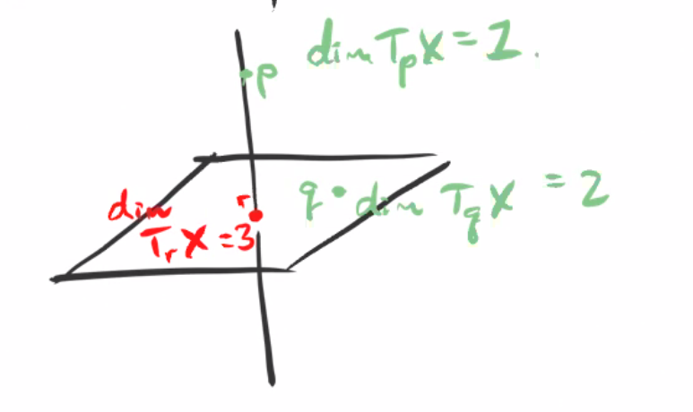

Union of Plane and Axis

Consider $X\mathrel{\vcenter{:}}= V(y^2 - x^3) \subset {\mathbb{A}}^2$:

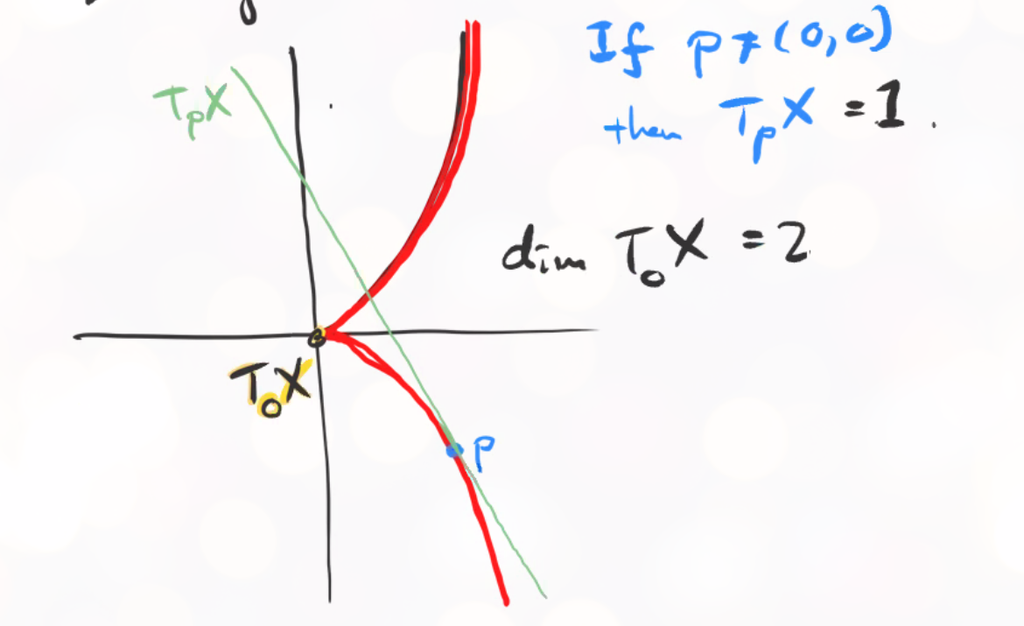

Note that $\dim T_0 X = 2$ is easy to see since it’s equal to $V\qty{f_1 {~\mathrel{\Big|}~}f\in \left\langle{y^2 - x^3}\right\rangle} = V(0) = k^2$. Thus $p\neq 0$ are smooth points and $p=0$ is the unique singular point. So $X$ is not smooth, but $X\setminus\left\{{0}\right\}$ is.

A local ring $R$ over a field $k$ is **regular** iff $\dim_k \mathfrak{m}/\mathfrak{m}^2 = \dim R$, the length of the longest chain of prime ideals. Note that we’ll add the additional assumption that $R/\mathfrak{m} \cong k$.

A variety $X$ is thus smooth iff $\dim_k \mathfrak{m}_p / \mathfrak{m}_p^2 = \dim_p X = \dim {\mathcal{O}}_{X, p}$.

A regular local ring is a UFD.

Each connected component of a smooth variety is irreducible.

If a connected component$X$ is not irreducible, then there exists a point $p\in X$ such that ${\mathcal{O}}_{X, p}$ is not a domain, and thus a nonzero pair $f, g \in {\mathcal{O}}_{X, p}$ such that $fg=0$. These exist by simply taking an indicator function on each component. So $0$ doesn’t have a unique factorization. So ${\mathcal{O}}_{X, p}$ is not regular, and thus $\dim T_p X > \dim_p X$, which is a contradiction.

How can we check if a variety $X$ is smooth then? Just checking dimensions from the definitions is difficult in general.

## 30.2 Checking Smoothness

Let $p\in X$ an affine variety embedded in ${\mathbb{A}}^n$, and suppose $I(X) = \left\langle{f_1, \cdots, f_r}\right\rangle$. Then $X$ is smooth at $p$ $\iff$ the matrix $\qty{{\frac{\partial f}{\partial x_j}\,}}\Big|_{p}$ has rank $n - \dim X$.

Is $V(x^2 - y^2 - 1) \subset {\mathbb{A}}^2$ smooth? We have $I(X) = \left\langle{f_1}\right\rangle \mathrel{\vcenter{:}}=\left\langle{x^2 - y^2 - 1}\right\rangle$, so let $p\in X$. Then consider the matrix
$$\begin{align*}
\begin{bmatrix}
J \mathrel{\vcenter{:}}=
{\frac{\partial f}{\partial x}\,} & {\frac{\partial f}{\partial y}\,} \\
\end{bmatrix} =
\begin{bmatrix}
2x & -2y \\
\end{bmatrix}
.\end{align*}
We want to show that at any \(p\in X\), we have \(\operatorname{rank}(J) = 1\). This is true for \(p\neq (0, 0)\), but this is not a point in \(X\).$$

Consider $X \mathrel{\vcenter{:}}= V(y^2 - x^3 + x^2) \subset {\mathbb{A}}^2$:

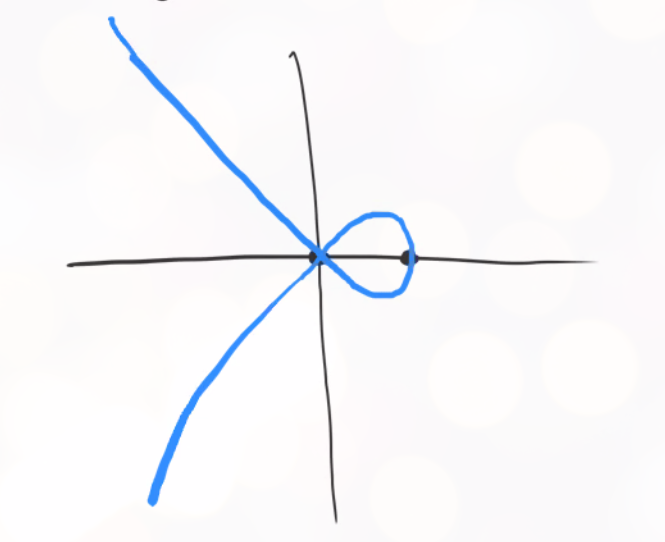

Image

Then $I(X) = \left\langle{y^2 - x^3 + x^2}\right\rangle = \left\langle{f}\right\rangle$, and
$$\begin{align*}
J =
\begin{bmatrix}
2y & -3x^2 + 2x \\
\end{bmatrix}
.\end{align*}
Then \(\operatorname{rank}(J) = 0\) at \(p = (0, 0)\), which is a point in \(X\), so \(X\) is not smooth.$$

Consider $X\mathrel{\vcenter{:}}= V(x^2 + y^2, 1+z^3) \subset{\mathbb{A}}^3$, then $I(X) = \left\langle{x^2 + y^2, 1 + z^3}\right\rangle \left\langle{f, g}\right\rangle$ which is clearly a radical ideal.

We then have
$$\begin{align*}
J =
\begin{bmatrix}
f_x & f_y & f_z \\
g_x & g_y & g_z \\
\end{bmatrix}
=
\begin{bmatrix}
2x & 2y & 0 \\
0 & 0 & 3z^2
\end{bmatrix}
,\end{align*}
and thus
\begin{align*}
\operatorname{rank}(J) =
\begin{cases}
0 & x=y=z=0 \\
1 & x=y=0 \text{ xor } z=0 \\
2 & \text{else}.
\end{cases}
\end{align*}$$

Thus the singular locus is $V(x^2 + y^2) = V((x+iy)(x-iy)) \cap V(1+z^3)$, which results in 3 singular points after intersecting:

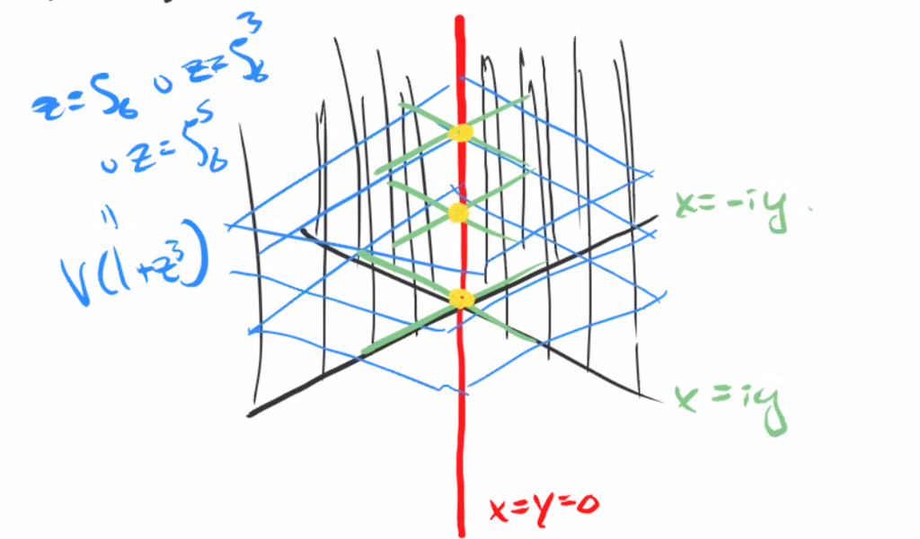

Image

Note that it doesn’t matter that $V(1+z^3)$ was intersected here, as long as it’s anything that intersects the $z{\hbox{-}}$axis nontrivially we will still get something singular.

# Appendix: Commutative Algebra

## 30.3 Useful Algebra Facts

- $\mathfrak{p}{~\trianglelefteq~}R$ is prime $\iff R/\mathfrak{p}$ is a domain.
- $\mathfrak{p}{~\trianglelefteq~}R$ is maximal $\iff R/\mathfrak{p}$ is a field.
- Maximal ideals are prime.
- Prime ideals are radical.
- If $R$ is a PID and $\left\langle{f}\right\rangle {~\trianglelefteq~}R$ is generated by an irreducible element $f$, then $\left\langle{f}\right\rangle$ is maximal

A polynomial ring $k[x_1, \cdots, x_{n}]$ on finitely many generators is Noetherian. In particular, every ideal $I{~\trianglelefteq~}k[x_1, \cdots, x_{n}]$ has a finite set of generators and can be written as $I = \left\langle{f_1, \cdots, f_m}\right\rangle$.

A field $k$ is both Artinian and Noetherian, since it has only two ideals and thus any chain of ideals necessarily terminates. By Hilbert’s basis theorem (), $k[x_1, \cdots, x_{n}]$ is thus Noetherian.

$$\begin{align*}
I+J &\mathrel{\vcenter{:}}=\left\{{f+g {~\mathrel{\Big|}~}f\in I,\, g\in J}\right\} \\
IJ &\mathrel{\vcenter{:}}=\left\{{\sum_{i=1}^N f_i g_i {~\mathrel{\Big|}~}f_i\in I,\, g_i\in J, N\in {\mathbb{N}}}\right\} \\
I+J = \left\langle{1}\right\rangle
&\implies I\cap J = IJ && \text{(coprime or comaximal)}
\left\langle{a}\right\rangle + \left\langle{b}\right\rangle = \left\langle{a, b}\right\rangle
.\end{align*}$$

Any finitely-generated field extension $k_1 \hookrightarrow k_2$ is a finite extension of a purely transcendental extension, i.e. there exist $t_1, \cdots, t_\ell$ such that $k_2$ is finite over $k_1(t_1, \cdots, t_\ell)$.

If $R$ is a Noetherian ring, then $R[x]$ is again Noetherian.

# 31 Appendix: Course Exercises

## 31.1 Problem Set 1

Prove that every affine variety $X\subset {\mathbb{A}}^n/k$ consisting of only finitely many points can be written as the zero locus of $n$ polynomials.

> Hint: Use interpolation. It is useful to assume at first that all points in $X$ have different $x_1{\hbox{-}}$coordinates.

Determine $\sqrt{I}$ for
$$\begin{align*}
I\mathrel{\vcenter{:}}=\left\langle{x_1^3 - x_2^6,\, x_1 x_2 - x_2^3}\right\rangle {~\trianglelefteq~}{\mathbb{C}}[x_1, x_2]
.\end{align*}$$

Let $X\subset {\mathbb{A}}^3/k$ be the union of the three coordinate axes. Compute generators for the ideal $I(X)$ and show that it can not be generated by fewer than 3 elements.

Let $Y\subset {\mathbb{A}}^n/k$ be an affine variety and define $A(Y)$ by the quotient
$$\begin{align*}
\pi: k[x_1,\cdots, x_n] \to A(Y) \mathrel{\vcenter{:}}= k[x_1, \cdots, x_n]/I(Y)
.\end{align*}$$

1. Show that $V_Y(J) = V(\pi^{-1}(J))$ for every $J{~\trianglelefteq~}A(Y)$.
2. Show that $\pi^{-1} (I_Y(X)) = I(X)$ for every affine subvariety $X\subseteq Y$.
3. Using the fact that $I(V(J)) \subset \sqrt{J}$ for every $J{~\trianglelefteq~}k[x_1, \cdots, x_n]$, deduce that $I_Y(V_Y(J)) \subset \sqrt{J}$ for every $J{~\trianglelefteq~}A(Y)$.

Conclude that there is an inclusion-reversing bijection
$$\begin{align*}
\left\{{\substack{\text{Affine subvarieties}\\ \text{of } Y}}\right\} \iff \left\{{\substack{\text{Radical ideals} \\ \text{in } A(Y)}}\right\}
.\end{align*}$$

Let $J {~\trianglelefteq~}k[x_1, \cdots, x_n]$ be an ideal, and find a counterexample to $I(V(J)) =\sqrt{J}$ when $k$ is not algebraically closed.

## 31.2 Problem Set 2

Find the irreducible components of
$$\begin{align*}
X = V(x - yz, xz - y^2) \subset {\mathbb{A}}^3/{\mathbb{C}}
.\end{align*}$$

Let $X\subset {\mathbb{A}}^n$ be an arbitrary subset and show that
$$\begin{align*}
V(I(X)) = \mkern 1.5mu\overline{\mkern-1.5muX\mkern-1.5mu}\mkern 1.5mu
.\end{align*}$$

Let $\left\{{U_i}\right\}_{i\in I} \rightrightarrows X$ be an open cover of a topological space with $U_i \cap U_j \neq \emptyset$ for every $i, j$.

1. Show that if $U_i$ is connected for every $i$ then $X$ is connected.
2. Show that if $U_i$ is irreducible for every $i$ then $X$ is irreducible.

Let $f:X\to Y$ be a continuous map of topological spaces.

1. Show that if $X$ is connected then $f(X)$ is connected.
2. Show that if $X$ is irreducible then $f(X)$ is irreducible.

Let $X$ be an affine variety.

1. Show that if $Y_1, Y_2 \subset X$ are subvarieties then
   $$\begin{align*}
   I(\mkern 1.5mu\overline{\mkern-1.5muY_1\setminus Y_2\mkern-1.5mu}\mkern 1.5mu) = I(Y_1): I(Y_2)
   .\end{align*}$$
2. If $J_1, J_2 {~\trianglelefteq~}A(X)$ are radical, then
   $$\begin{align*}
   \mkern 1.5mu\overline{\mkern-1.5muV(J_1) \setminus V(J_2)\mkern-1.5mu}\mkern 1.5mu = V(J_1: J_2)
   .\end{align*}$$

Let $X \subset {\mathbb{A}}^n,\, Y\subset {\mathbb{A}}^m$ be irreducible affine varieties, and show that $X\times Y\subset {\mathbb{A}}^{n+m}$ is irreducible.

## 31.3 Problem Set 3

Define
$$\begin{align*}
X \mathrel{\vcenter{:}}=\left\{{M \in \operatorname{Mat}(2\times 3, k) {~\mathrel{\Big|}~}{\operatorname{rank}}M \leq 1}\right\} \subseteq {\mathbb{A}}^6/k
.\end{align*}$$

Show that $X$ is an irreducible variety, and find its dimension.

Let $X$ be a topological space, and show

1. If $\left\{{U_i}\right\}_{i\in I} \rightrightarrows X$, then $\dim X = \sup_{i\in I} \dim U_i$.
2. If $X$ is an irreducible affine variety and $U\subset X$ is a nonempty subset, then $\dim X = \dim U$. Does this hold for any irreducible topological space?

Prove the following:

1. Every noetherian topological space is compact. In particular, every open subset of an affine variety is compact in the Zariski topology.
2. A complex affine variety of dimension at least 1 is never compact in the classical topology.

Let
$$\begin{align*}
R = k[x_1, x_2, x_3, x_4] / \left\langle{x_1 x_4 - x_2 x_3}\right\rangle
\end{align*}
and show the following:$$

1. $R$ is an integral domain of dimension 3.
2. $x_1, \cdots, x_4$ are irreducible but not prime in $R$, and thus $R$ is not a UFD.
3. $x_1 x_4$ and $x_2 x_3$ are two decompositions of the same element in $R$ which are nonassociate.
4. $\left\langle{x_1, x_2}\right\rangle$ is a prime ideal of codimension 1 in $R$ that is not principal.

Consider a set $U$ in the complement of $(0, 0) \in {\mathbb{A}}^2$. Prove that any regular function on $U$ extends to a regular function on all of ${\mathbb{A}}^2$.

## 31.4 Problem Set 4

Let $X\subset {\mathbb{A}}^n$be an affine variety and $a\in X$. Show that
$$\begin{align*}
{\mathcal{O}}_{X, a} = {\mathcal{O}}_{{\mathbb{A}}^n, a} / I(X) {\mathcal{O}}_{A^n,a}
,\end{align*}
where \(I(X) {\mathcal{O}}_{{\mathbb{A}}^n, a}\) denotes the ideal in \({\mathcal{O}}_{{\mathbb{A}}^n, a}\) generated by all quotients \(f/1\) for \(f\in I(X)\).$$

Let $a\in {\mathbb{R}}$, and consider sheaves $\mathcal{F}$ on ${\mathbb{R}}$ with the standard topology:

1. $\mathcal{F} \mathrel{\vcenter{:}}=$ the sheaf of continuous functions
2. $\mathcal{F} \mathrel{\vcenter{:}}=$ the sheaf of locally polynomial functions.

For which is the stalk $\mathcal{F}_a$ a local ring?

> Recall that a local ring has precisely one maximal ideal.

Let $\phi, \psi \in \mathcal{F}(U)$ be two sections of some sheaf $\mathcal{F}$ on an open $U\subseteq X$ and show that

1. If $\phi, \psi$ agree on all stalks, so $\mkern 1.5mu\overline{\mkern-1.5mu(U, \phi)\mkern-1.5mu}\mkern 1.5mu = \mkern 1.5mu\overline{\mkern-1.5mu(U, \psi)\mkern-1.5mu}\mkern 1.5mu \in \mathcal{F}_a$ for all $a\in U$, then $\phi$ and $\psi$ are equal.
2. If $\mathcal{F} \mathrel{\vcenter{:}}={\mathcal{O}}_X$ is the sheaf of regular functions on some irreducible affine variety $X$, then if $\psi = \phi$ on one stalk $\mathcal{F}_a$, then $\phi = \psi$ everywhere.
3. For a general sheaf $\mathcal{F}$ on $X$, (b) is false.

Let $Y\subset X$ be a nonempty and irreducible subvariety of an affine variety $X$, and show that the stalk ${\mathcal{O}}_{X, Y}$ of ${\mathcal{O}}_X$ at $Y$ is a $k{\hbox{-}}$algebra which is isomorphic to the localization $A(X)_{I(Y)}$.

Let $\mathcal{F}$ be a sheaf on $X$ a topological space and $a\in X$. Show that the stalk $\mathcal{F}_a$ is a *local object*, i.e. if $U\subset X$ is an open neighborhood of $a$, then $\mathcal{F}_a$ is isomorphic to the stalk of ${ \left.{{ \mathcal{F} }} \right|_{{U}} }$ at $a$ on $U$ viewed as a topological space.

## 31.5 Problem Set 5

Let $f:X\to Y$ be a morphism of affine varieties and $f^*: A(Y) \to A(X)$ the induced map on coordinate rings. Determine if the following statements are true or false:

1. $f$ is surjective $\iff f^*$ is injective.
2. $f$ is injective $\iff f^*$ is surjective.
3. If $f:{\mathbb{A}}^1\to{\mathbb{A}}^1$ is an isomorphism, then $f$ is *affine linear*, i.e. $f(x) = ax+b$ for some $a, b\in k$.
4. If $f:{\mathbb{A}}^2\to{\mathbb{A}}^2$ is an isomorphism, then $f$ is *affine linear*, i.e. $f(x) = Ax+b$ for some $a \in \operatorname{Mat}(2\times 2, k)$ and $b\in k^2$.

Which of the following are isomorphic as ringed spaces over ${\mathbb{C}}$?

1. $\mathbb{A}^{1} \backslash\{1\}$
2. $V\left(x_{1}^{2}+x_{2}^{2}\right) \subset \mathbb{A}^{2}$
3. $V\left(x_{2}-x_{1}^{2}, x_{3}-x_{1}^{3}\right) \backslash\{0\} \subset \mathbb{A}^{3}$
4. $V\left(x_{1} x_{2}\right) \subset \mathbb{A}^{2}$
5. $V\left(x_{2}^{2}-x_{1}^{3}-x_{1}^{2}\right) \subset \mathbb{A}^{2}$
6. $V\left(x_{1}^{2}-x_{2}^{2}-1\right) \subset \mathbb{A}^{2}$

Show that

1. Every morphism $f:{\mathbb{A}}^1\setminus\left\{{0}\right\}\to {\mathbb{P}}^1$ can be extended to a morphism $\widehat{f}: {\mathbb{A}}^1 \to {\mathbb{P}}^1$.
2. Not every morphism $f:{\mathbb{A}}^2\setminus\left\{{0}\right\}\to {\mathbb{P}}^1$ can be extended to a morphism $\widehat{f}: {\mathbb{A}}^2 \to {\mathbb{P}}^1$.
3. Every morphism ${\mathbb{P}}^1\to {\mathbb{A}}^1$ is constant.

Show that

1. Every isomorphism $f:{\mathbb{P}}^1\to {\mathbb{P}}^1$ is of the form
   $$\begin{align*}
   f(x) = {ax+b \over cx+d} && a,b,c,d\in k
   .\end{align*}
   where \(x\) is an affine coordinate on \({\mathbb{A}}^1\subset {\mathbb{P}}^1\).$$
2. Given three distinct points $a_i \in {\mathbb{P}}^1$ and three distinct points $b_i \in {\mathbb{P}}^1$, there is a unique isomorphism $f:{\mathbb{P}}^1 \to {\mathbb{P}}^1$ such that $f(a_i) = b_i$ for all $i$.

There is a bijection
$$\begin{align*}
\left\{{ \text { morphisms } X \rightarrow Y }\right\}
&\stackrel{1: 1}{\leftrightarrow}
\left\{{ K{\hbox{-}}\text{algebra morphisms } \mathscr{O}_{Y}(Y) \rightarrow \mathscr{O}_{X}(X) }\right\} \\
f &\mapsto f^{*}
\end{align*}$$

Does the above bijection hold if

1. $X$ is an arbitrary prevariety but $Y$ is still affine?
2. $Y$ is an arbitrary prevariety but $X$ is still affine?

# 32 Bibliography

1.

Gathmann, A.: Algebraic geometry. (2019)